# PS6

2024-05-18

## 1.1

```r
scripps <- read.delim("scripps-co2.csv")
head(scripps)
```

```
##   year month date..excel. date..year.    co2 co2..seasonally.adjusted.
## 1 1958     1        21200    1958.041 -99.99                    -99.99
## 2 1958     2        21231    1958.126 -99.99                    -99.99
## 3 1958     3        21259    1958.203 315.71                    314.44
## 4 1958     4        21290    1958.288 317.45                    315.16
## 5 1958     5        21320    1958.370 317.51                    314.69
## 6 1958     6        21351    1958.455 -99.99                    -99.99
##   co2..seasonal..smoothed. co2..smoothed. co2..filled. co2..adjusted..filled.
## 1                   -99.99         -99.99       -99.99                 -99.99
## 2                   -99.99         -99.99       -99.99                 -99.99
## 3                   316.20         314.91       315.71                 314.44
## 4                   317.30         314.99       317.45                 315.16
## 5                   317.89         315.07       317.51                 314.69
## 6                   317.27         315.15       317.27                 315.15
##   station
## 1     MLO
## 2     MLO
## 3     MLO
## 4     MLO
## 5     MLO
## 6     MLO
```

```r
library(dplyr)
scripps2 <- scripps %>%
  select(year, month, co2)
head(scripps2)
```

```
##   year month    co2
## 1 1958     1 -99.99
## 2 1958     2 -99.99
## 3 1958     3 315.71
## 4 1958     4 317.45
## 5 1958     5 317.51
## 6 1958     6 -99.99
```

## 1.2

Each row in this data set represents a monthly CO2 measurement at a different date and time.

## 1.1.5

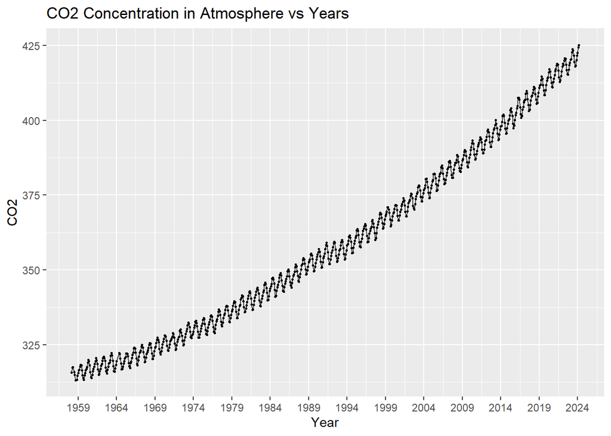

```r
library(ggplot2)
scripps2 %>%
  filter(as.numeric(co2) > 0) %>%
  mutate(months = as.Date(paste(year, month, "01", sep = "-"))) %>%
  ggplot(aes(months, co2)) +
  geom_line(alpha = 0.7) +
  geom_point(size = 0.6) +
  scale_x_date(date_labels = "%Y", date_breaks = "5 year") +
  labs(title = "CO2 Concentration in Atmosphere vs Years", x = "Year", y = "CO2")
```

## 1.1.6

Each year the, CO2 level has been increasing from 1958 till 2023.

## 1.2.1

```r
hadcrut <- read.delim("hadcrut-5.0.2.0-annual.csv")
head(hadcrut)
```

```
##   Time Anomaly..deg.C. Lower.confidence.limit..2.5..
## 1 1850      -0.4177114                    -0.5892565
## 2 1851      -0.2333498                    -0.4118679
## 3 1852      -0.2293991                    -0.4093824
## 4 1853      -0.2703545                    -0.4300093
## 5 1854      -0.2915208                    -0.4327115
## 6 1855      -0.2969168                    -0.4393188
##   Upper.confidence.limit..97.5..
## 1                    -0.24616630
## 2                    -0.05483169
## 3                    -0.04941572
## 4                    -0.11069953
## 5                    -0.15033019
## 6                    -0.15451474
```

```r
library(dplyr)
hadcrut2 <- hadcrut %>%
  select(year = Time, Anomaly = Anomaly..deg.C.) %>%
  rename(temperature_anomaly = Anomaly)
head(hadcrut2)
```

```
##   year temperature_anomaly
## 1 1850          -0.4177114
## 2 1851          -0.2333498
## 3 1852          -0.2293991
## 4 1853          -0.2703545
## 5 1854          -0.2915208
## 6 1855          -0.2969168
```

## 1.2.2

Each line represents each years temperature anomaly

## 1.2.3

1850 to 2023

## 1.2.4

```r
library(dplyr)
preIndustrial <- hadcrut2 %>%
  filter(year <= 1900) %>%
  summarise(preIndustrialAvg = mean(temperature_anomaly, na.rm = TRUE))
preIndustrial
```

```
##   preIndustrialAvg
## 1       -0.3564947
```

```r
hadcrut2 <- hadcrut2 %>%
  mutate(anomaly_over_preindustrial = temperature_anomaly - preIndustrial$preIndustrial)
head(hadcrut2)
```

```
##   year temperature_anomaly anomaly_over_preindustrial
## 1 1850          -0.4177114                -0.06121666
## 2 1851          -0.2333498                 0.12314494
## 3 1852          -0.2293991                 0.12709567
## 4 1853          -0.2703545                 0.08614029
## 5 1854          -0.2915208                 0.06497391
## 6 1855          -0.2969168                 0.05957799
```

## 1.2.5

It means that the average global temperature during the pre industrial period is lower than the reference period average.

## 1.2.6

```r
library(dplyr)
pre_industrial_data <- hadcrut2 %>% filter(year <= 1900)
pre_industrial_baseline <- mean(pre_industrial_data$temperature_anomaly, na.rm = TRUE)
cat("Pre-Industrial Baseline (°C):", pre_industrial_baseline, "\n")
```

```
## Pre-Industrial Baseline (°C): -0.3564947
```

```r
hadcrut2 <- hadcrut2 %>%
  mutate(Temp_Anomaly_Pre_Industrial = temperature_anomaly - pre_industrial_baseline)

head(hadcrut)
```

```
##   Time Anomaly..deg.C. Lower.confidence.limit..2.5..
## 1 1850      -0.4177114                    -0.5892565
## 2 1851      -0.2333498                    -0.4118679
## 3 1852      -0.2293991                    -0.4093824
## 4 1853      -0.2703545                    -0.4300093
## 5 1854      -0.2915208                    -0.4327115
## 6 1855      -0.2969168                    -0.4393188
##   Upper.confidence.limit..97.5..
## 1                    -0.24616630
## 2                    -0.05483169
## 3                    -0.04941572
## 4                    -0.11069953
## 5                    -0.15033019
## 6                    -0.15451474
```

## 1.2.7

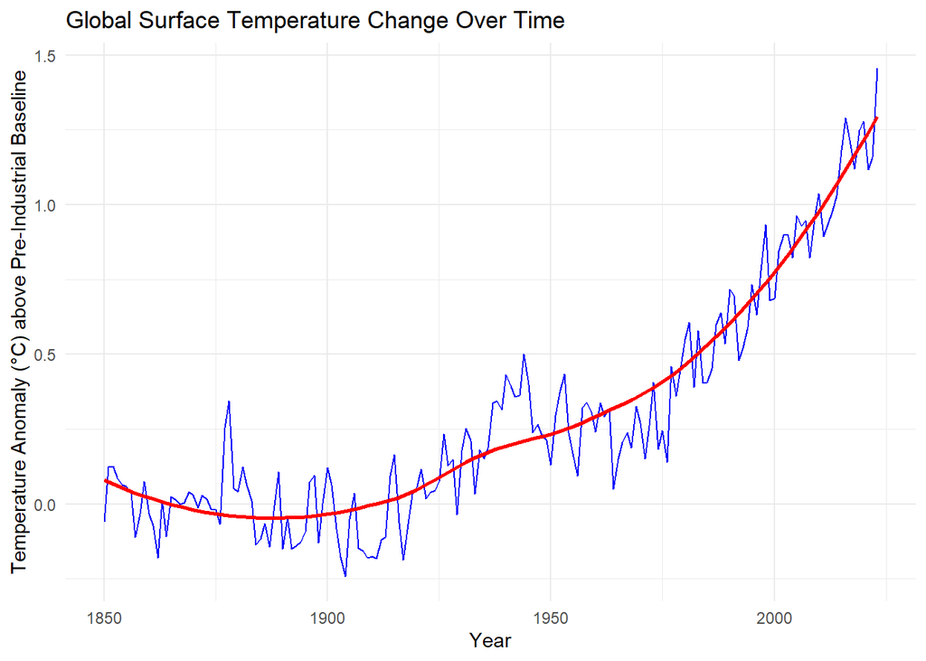

```r
library(dplyr)
library(ggplot2)

hadcrut2 <- hadcrut2 %>%
  mutate(Temp_Anomaly_Pre_Industrial = temperature_anomaly - pre_industrial_baseline)

# Plot the data
ggplot(hadcrut2, aes(x = year, y = Temp_Anomaly_Pre_Industrial)) +
  geom_line(color = "blue") +
  geom_smooth(method = "loess", color = "red", se = FALSE) +
  labs(title = "Global Surface Temperature Change Over Time",
       x = "Year",
       y = "Temperature Anomaly (°C) above Pre-Industrial Baseline") +
  theme_minimal()
```

## 1.2.8

Over 170 years, the global temperature has slowly increase from 1850 to around 1960. After that the temperature rises higher.

## 1.3.1

I would use the variable year to merge co2 data with global temperature.

## 1.3.2

By creating a new variable for the data set that represents the year

## 1.3.3

```r
library(dplyr)
library(ggplot2)
CO2_Year <- scripps2 %>%
  group_by(year) %>%
  summarize(avg_co2_yearly = mean(co2, na.rm = TRUE))
 merger <- left_join(hadcrut2, CO2_Year)
```

I did a left join as it allows us to combine using the year variable.

## 1.3.4

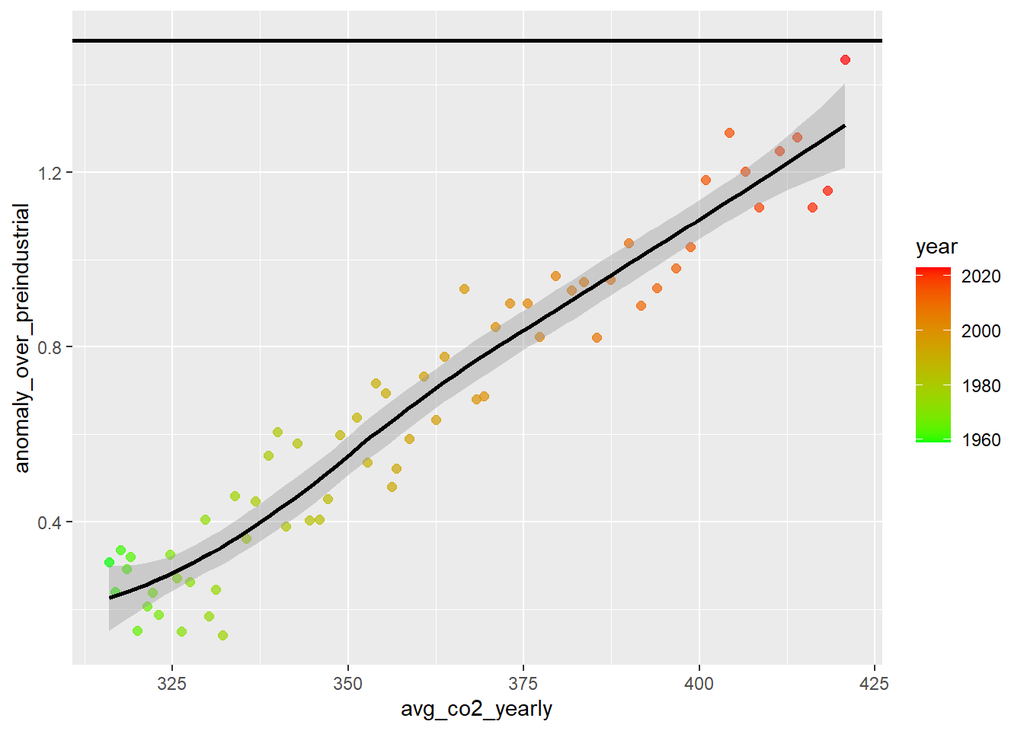

```r
library(dplyr)
library(ggplot2)
merger %>%
  filter(avg_co2_yearly >= 300) %>%
  ggplot(aes(avg_co2_yearly, anomaly_over_preindustrial, col = year)) +
  geom_point(size = 2, alpha = 0.7) +
  geom_smooth(color = "black") +
  geom_hline(yintercept = 1.5, color = "black", size = 1) +
  scale_alpha_continuous(name = "decades") +
  scale_color_gradient(low = "green", high = "red")
```

## 2.1

```r
library(dplyr)
UAH <- read.delim("UAH-lower-troposphere-wide_2023-11-07.csv") %>%
  select(year,month,globe)
head(UAH)
```

```
##   year month globe
## 1 1978    12 -0.48
## 2 1979     1 -0.48
## 3 1979     2 -0.44
## 4 1979     3 -0.39
## 5 1979     4 -0.41
## 6 1979     5 -0.40
```

## 2.2

```r
library(dplyr)
UAHaverages <- UAH %>%
  group_by(year) %>%
  summarize(lowerTroposphere = mean(globe))
UAHaverages %>%
  head()
```

```
## # A tibble: 6 × 2
##    year lowerTroposphere
##   <int>            <dbl>
## 1  1978           -0.48
## 2  1979           -0.348
## 3  1980           -0.179
## 4  1981           -0.249
## 5  1982           -0.435
## 6  1983           -0.18
```

## 2.3

```r
library(dplyr)
hadcrut2$surface <- hadcrut2$anomaly
UAHHadcrut2 <- left_join(UAHaverages, hadcrut2, by = "year") %>%
  select(!c(anomaly_over_preindustrial,temperature_anomaly))
UAHHadcrut2 %>%
  head()
```

```
## # A tibble: 6 × 4
##    year lowerTroposphere Temp_Anomaly_Pre_Industrial surface
##   <int>            <dbl>                       <dbl>   <dbl>
## 1  1978           -0.48                        0.362   0.362
## 2  1979           -0.348                       0.447   0.447
## 3  1980           -0.179                       0.553   0.553
## 4  1981           -0.249                       0.607   0.607
## 5  1982           -0.435                       0.391   0.391
## 6  1983           -0.18                        0.580   0.580
```

## 2.4

Data set is in wide form as seen when opening up the data set from the environment.

## 2.5

```r
library(dplyr)
library(magrittr)
library(tidyverse)
LongUAHHadcrut <- UAHHadcrut2 %>%
  pivot_longer(!c(year),names_to="type",values_to="anomaly")
LongUAHHadcrut %>%
  head()
```

```
## # A tibble: 6 × 3
##    year type                        anomaly
##   <int> <chr>                         <dbl>
## 1  1978 lowerTroposphere             -0.48
## 2  1978 Temp_Anomaly_Pre_Industrial   0.362
## 3  1978 surface                       0.362
## 4  1979 lowerTroposphere             -0.348
## 5  1979 Temp_Anomaly_Pre_Industrial   0.447
## 6  1979 surface                       0.447
```

## 2.6

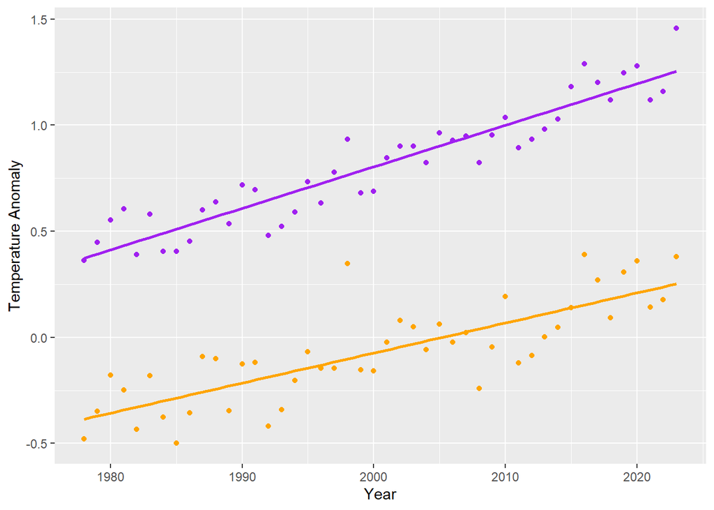

```r
library(dplyr)
library(ggplot2)
UAHHadcrut2 %>%
  ggplot()+
  geom_point(aes(year,lowerTroposphere),
             color="orange")+
  geom_smooth(aes(year,lowerTroposphere),
                  method="lm",se=FALSE,color="orange")+
  geom_point(aes(year,surface),
             color="purple")+
  geom_smooth(aes(year,surface),
                  method="lm",se=FALSE,color="purple")+
    labs(
    x="Year",
    y="Temperature Anomaly",
  )
```

## 3.1

```r
baby <- read.delim("babynames.csv")
head(baby)
```

```
##   year sex      name    n       prop
## 1 1880   F      Mary 7065 0.07238359
## 2 1880   F      Anna 2604 0.02667896
## 3 1880   F      Emma 2003 0.02052149
## 4 1880   F Elizabeth 1939 0.01986579
## 5 1880   F    Minnie 1746 0.01788843
## 6 1880   F  Margaret 1578 0.01616720
```

```r
library(dplyr)
filtered_baby_data <- baby %>%
  filter(name %in% c("Mary", "Emma"))
head(filtered_baby_data)
```

```
##   year sex name    n       prop
## 1 1880   F Mary 7065 0.07238359
## 2 1880   F Emma 2003 0.02052149
## 3 1880   M Mary   27 0.00022804
## 4 1880   M Emma   10 0.00008446
## 5 1881   F Mary 6919 0.06999140
## 6 1881   F Emma 2034 0.02057559
```

## 3.2

```r
library(dplyr)
library(magrittr)
library(tidyverse)
wide_baby_data <- filtered_baby_data %>%
  pivot_wider(names_from = name, values_from = n)
head(wide_baby_data)
```

```
## # A tibble: 6 × 5
##    year sex        prop  Mary  Emma
##   <int> <chr>     <dbl> <int> <int>
## 1  1880 F     0.0724     7065    NA
## 2  1880 F     0.0205       NA  2003
## 3  1880 M     0.000228     27    NA
## 4  1880 M     0.0000845    NA    10
## 5  1881 F     0.0700     6919    NA
## 6  1881 F     0.0206       NA  2034
```

## 3.3

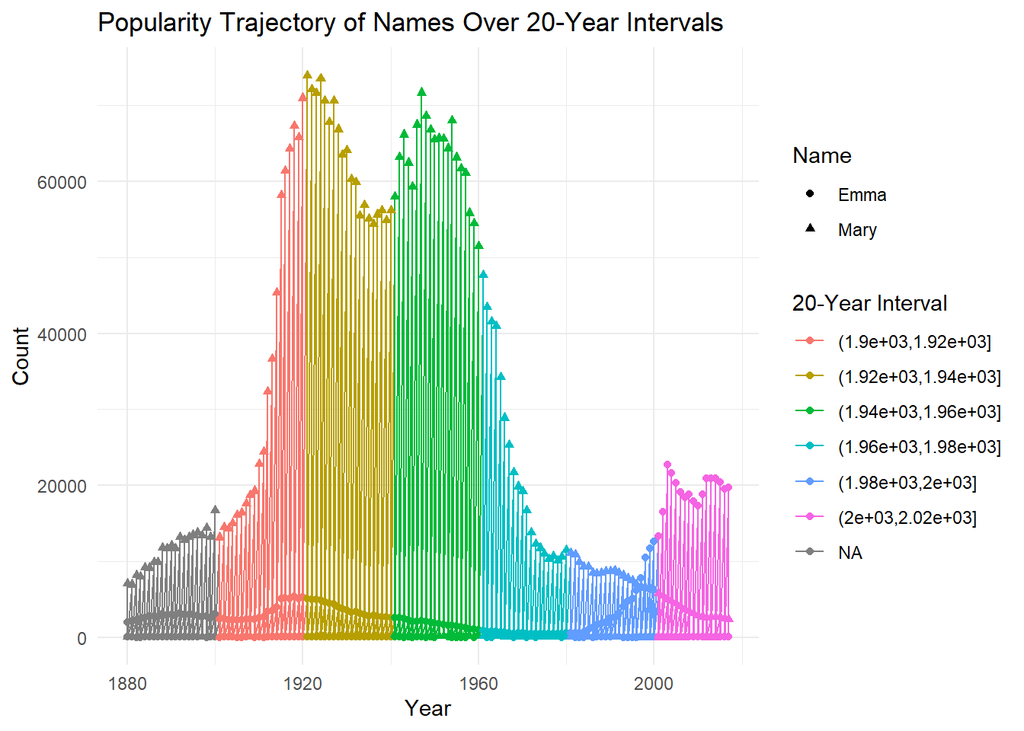

```r
library(dplyr)
library(ggplot2)

filtered_baby_data$interval <- cut(filtered_baby_data$year, breaks = seq(1900, 2020, by = 20))
ggplot(filtered_baby_data, aes(x = year, y = n, color = interval, shape = name)) +
  geom_line(aes(group = name)) +
  geom_point() +
  scale_color_discrete(name = "20-Year Interval") +
  labs(title = "Popularity Trajectory of Names Over 20-Year Intervals",
       x = "Year",
       y = "Count",
       shape = "Name") +
  theme_minimal()
```

## 3.4

Before 2000, Mary would easily be a much more popular named compared to Emma. However, suddenly, in the 2000s, Emma became much more popular of a name compared to Mary.